# 10장 기계학습 알고리즘1

jihyun

2019 8 28

## 1. 로지스틱 회기모델

아이리스 데이터로부터 로지스틱 회기 모델을 작성해 보자

```r
data(iris)
head(iris)
```

```
##   Sepal.Length Sepal.Width Petal.Length Petal.Width Species
## 1          5.1         3.5          1.4         0.2  setosa
## 2          4.9         3.0          1.4         0.2  setosa
## 3          4.7         3.2          1.3         0.2  setosa
## 4          4.6         3.1          1.5         0.2  setosa
## 5          5.0         3.6          1.4         0.2  setosa
## 6          5.4         3.9          1.7         0.4  setosa
```

sepal.length, sepal.width, petal.length, petal.width 로 species를 예측하는 모델을 만들어 보자.

로지스틱 회기 모델은 두 종류의 예측값만 구별이 가능하므로, virginica, versicolor 두 종류만 남긴다.

[output not shown]

Species 의 factor종류가 3개 이므로 2개로 수정해준다.

```r
d$Species <- factor(d$Species)
str(d)
```

```
## 'data.frame':    100 obs. of  5 variables:
##  $ Sepal.Length: num  7 6.4 6.9 5.5 6.5 5.7 6.3 4.9 6.6 5.2 ...
##  $ Sepal.Width : num  3.2 3.2 3.1 2.3 2.8 2.8 3.3 2.4 2.9 2.7 ...
##  $ Petal.Length: num  4.7 4.5 4.9 4 4.6 4.5 4.7 3.3 4.6 3.9 ...
##  $ Petal.Width : num  1.4 1.5 1.5 1.3 1.5 1.3 1.6 1 1.3 1.4 ...
##  $ Species     : Factor w/ 2 levels "versicolor","virginica": 1 1 1 1 1 1 1 1 1 1 ...
```

모델을 만들어 보자.

```r
(m <- glm(Species ~ ., data = d, family = 'binomial'))
```

```
##
## Call:  glm(formula = Species ~ ., family = "binomial", data = d)
##
## Coefficients:
##  (Intercept)  Sepal.Length   Sepal.Width  Petal.Length   Petal.Width
##      -42.638        -2.465        -6.681         9.429        18.286
##
## Degrees of Freedom: 99 Total (i.e. Null);  95 Residual
## Null Deviance:       138.6
## Residual Deviance: 11.9  AIC: 21.9
```

모델dl 적합된 값은 fittied()를 통해 알 수 있다.

```r
fitted(m)[c(1:5, 51:55)]
```

```
##           51           52           53           54           55
## 1.171672e-05 4.856237e-05 1.198626e-03 4.220049e-05 1.408470e-03
##          101          102          103          104          105
## 1.000000e+00 9.996139e-01 9.999990e-01 9.997188e-01 9.999999e-01
```

train데이터 중 일부를 test데이터 처럼 사용해 보자. predict()를 통해 모델에 예측을 시킬 수 있다. type 을 response로 지정하고 예측을 수행하면 0~1 사이의 확률을 구해준다.

```r
predict(m, newdata = d[c(1,10,55),], type = "response")
```

```
##           51           60          105
## 1.171672e-05 1.481064e-05 9.999999e-01
```

앞의 두개와는 근사값이 0, 뒤의 55번째는 근사값이 1로 두 종이 다른것을 잘 구별했다고 할 수 있다.

## 2. 다항 로지스틱 회기 분석

위의 로지스틱 회기 분석은 yes/no의 대답만 할 수있다. 하지만 이를 확장하면 다항 로지스틱 회기 분석을 할 수 있다.

iris data를 이용해 다항 로지스틱 회기 분석을 해 보자.

```r
library(nnet)
(m <- multinom(Species ~ ., data=iris))
```

```
## Call:
## multinom(formula = Species ~ ., data = iris)
##
## Coefficients:
##            (Intercept) Sepal.Length Sepal.Width Petal.Length Petal.Width
## versicolor    18.69037    -5.458424   -8.707401     14.24477   -3.097684
## virginica    -23.83628    -7.923634  -15.370769     23.65978   15.135301
##
## Residual Deviance: 11.89973
## AIC: 31.89973
```

적성한 모델이 훈련데이터에 어떻게 적합되었는지는 fitted()를 통해 구할 수 있다.

```r
head(fitted(m))
```

```
##      setosa   versicolor    virginica
## 1 1.0000000 1.526406e-09 2.716417e-36
## 2 0.9999996 3.536476e-07 2.883729e-32
## 3 1.0000000 4.443506e-08 6.103424e-34
## 4 0.9999968 3.163905e-06 7.117010e-31
## 5 1.0000000 1.102983e-09 1.289946e-36
## 6 1.0000000 3.521573e-10 1.344907e-35
```

fitted()의 결과는 각 행의 데이터가 각 분류에 속할 확률을 말한다. 위의 결과로 보면 첫 6개의 행은 전부 setosa종인 확률이 높은 것으로 보인다.

다음은 predict()로 각 종의 데이터 한 행씩을 뽑아 예측을 하게 해보자

```r
  predict(m, newdata = iris[c(1,51,101),],type = 'class')
```

```
## [1] setosa     versicolor virginica
## Levels: setosa versicolor virginica
```

type에 probs를 두면 확률을 알 수 있다.

```r
  predict(m, newdata = iris[c(1,51,101),],type = 'probs')
```

```
##           setosa   versicolor    virginica
## 1   1.000000e+00 1.526406e-09 2.716417e-36
## 51  2.427101e-07 9.999877e-01 1.201699e-05
## 101 9.453717e-25 2.718072e-10 1.000000e+00
```

모델의 정확도를 구해보자. 정확도는 예측값과 실제값의 차이를 통해 알 수 있다.

```r
predicted <- predict(m, newdata = iris)
sum(predicted == iris$Species)/NROW(predicted)
```

```
## [1] 0.9866667
```

세부적인 표는 xtabs를 통해 볼 수있다.

```r
xtabs(~predicted + iris$Species)
```

```
##             iris$Species
## predicted    setosa versicolor virginica
##   setosa         50          0         0
##   versicolor      0         49         1
##   virginica       0          1        49
```

## 3. 의사결정나무

의사결정나무는 지니 불순도(Gini Impurity), 또는 정보이득(Information Gain)등의 기준을 사용하여 노드를 재귀적으로 분할하면서 나무 모델을 만드는 방법이다. 의사결정나무는 if-else와 같은 조건문 형태라서 이해하기 쉽고, 속도가 빠르며, 특히 나무 모델 중 random forest는 꽤 괜찮은 성능을 보여주어 캐글에서도 많이 쓰인다고 알려져 있다.

의사결정나무를 이해하는데 도움이 되는 용어들

- 루트노드 : 최상단에 위치한 노드
- 리프노드 : 더이상 자식 노드가 없는 노드
- 불순도 : 지니 불순도를 이용하여 주로 계산한다(지니 불순도는 f(p) = p(1-p)로 정의 되며, 노드에 서로 다른 특징들이 절반씩 있을때 가장 높아지는 그래프 형태이다.). 불순도를 생각했을 때 노드를 나누는 가장 좋은 질문은 자식 노드들의 불순도가 가장 낮아지는 질문이다.

### 가장 일반적인 의사결정나무(rpart 패키지 이용)

아이리스 데이터에 대해 rpart를 이용해 의사결정 나무를 작성해 보자.

```r
#install.packages("rpart")
library(rpart)
(m<-rpart(Species ~ ., data = iris,))
```

```
## n= 150
##
## node), split, n, loss, yval, (yprob)
##       * denotes terminal node
##
## 1) root 150 100 setosa (0.33333333 0.33333333 0.33333333)
##   2) Petal.Length< 2.45 50   0 setosa (1.00000000 0.00000000 0.00000000) *
##   3) Petal.Length>=2.45 100  50 versicolor (0.00000000 0.50000000 0.50000000)
##     6) Petal.Width< 1.75 54   5 versicolor (0.00000000 0.90740741 0.09259259) *
##     7) Petal.Width>=1.75 46   1 virginica (0.00000000 0.02173913 0.97826087) *
```

위의 내용을 plot(), rpart.plot() 함수를 이용하면 좀 더 쉽게 볼 수 있다.

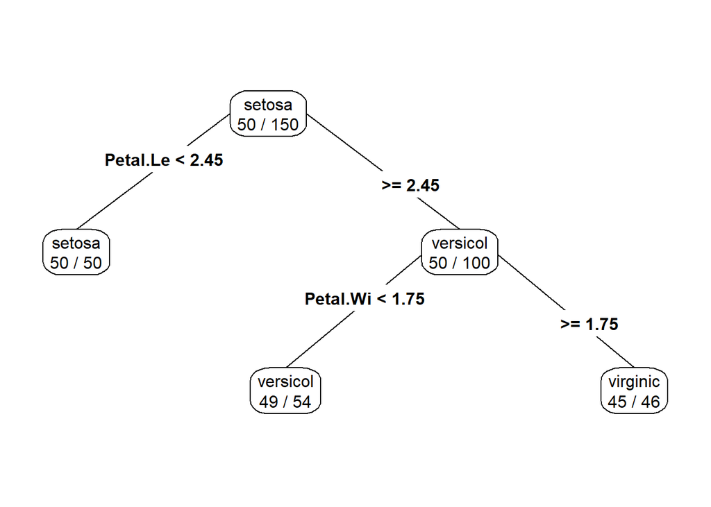

```r
#install.packages("rpart.plot")
library(rpart.plot)
prp(m, type = 4, extra=2, digits =3)
```

rpart 또한 predict()를 통해 예측을 어떻게 했는지 볼 수 있다.

```r
head(predict(m, newdata = iris, type = 'class'))
```

```
##      1      2      3      4      5      6
## setosa setosa setosa setosa setosa setosa
## Levels: setosa versicolor virginica
```

의사결정나무의 성능을 높이는 방법으로는 prunnung, rpart.control 등의 성능튜닝 방법이 있다.

### 조건부 추론 나무

조건부 추론 나무는 CART(rpart가 구현한 의사 결정 나무 알고리즘) 같은 의사결정나무의 두가지 문제를 해결한다. 1. 통계적유의성 없이 노드룰 분할하는 데에 따른 과적합 2. 다양한 값으로 분할 가능한 변수가 다른 변수들에 비해 선호되는 문제

조건부 추로 ㄴ나무는 조건부 분포에 따라 노드 분할에 사용할 변수를 선택한다. 또한 다중가설검정을 고려한 절차를 이용해서 적당한 시기에 노드의 분활을 중지한다.

아이리스 데이터에 ctree()fmf 적용하여 species 예측 모델을 만들어 보자.

```r
#install.packages('party')
library(party)
(m <- ctree(Species ~ ., data = iris))
```

```
##
##   Conditional inference tree with 4 terminal nodes
##
## Response:  Species
## Inputs:  Sepal.Length, Sepal.Width, Petal.Length, Petal.Width
## Number of observations:  150
##
## 1) Petal.Length <= 1.9; criterion = 1, statistic = 140.264
##   2)*  weights = 50
## 1) Petal.Length > 1.9
##   3) Petal.Width <= 1.7; criterion = 1, statistic = 67.894
##     4) Petal.Length <= 4.8; criterion = 0.999, statistic = 13.865
##       5)*  weights = 46
##     4) Petal.Length > 4.8
##       6)*  weights = 8
##   3) Petal.Width > 1.7
##     7)*  weights = 46
```

plot()을 통해 만들어진 모델을 보기쉽게 나타낼 수 있다.

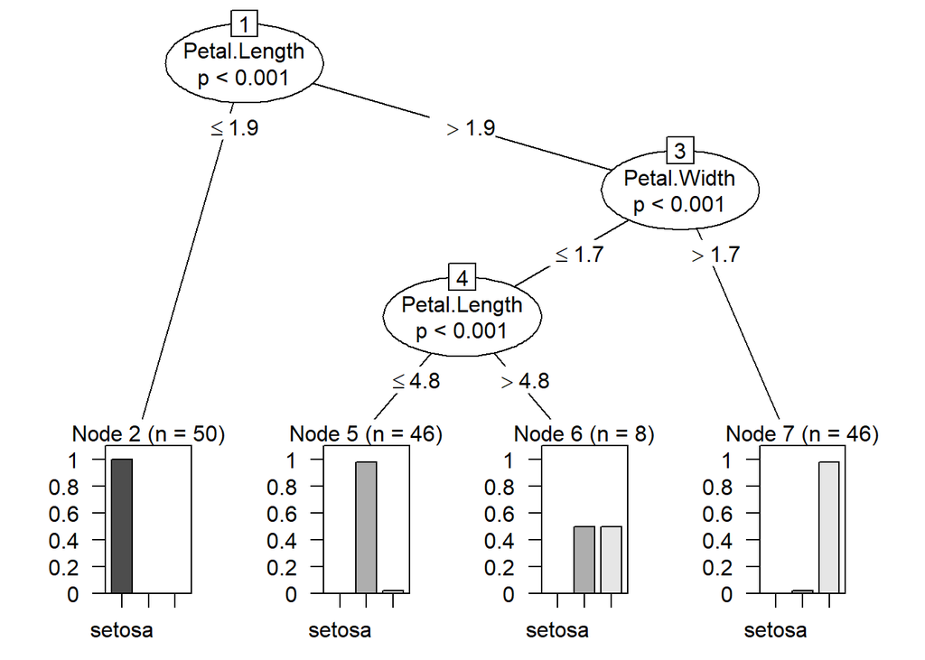

```r
plot(m)
```

```r
# plot의 그래프에 칸이 좁아서 setosa밖에보이지 않는 문제는 levles(iris$Species)를 통해 생략된 정보를 알 수 있다.
```